# call center

```python
import numpy as np
import pandas as pd
import matplotlib.pyplot as plt
```

```python
# Importing Data
call_center=pd.read_excel("Call Center.xlsx")
call_center
```

|  | Unnamed: 0 | Unnamed: 1 | Unnamed: 2 | Unnamed: 3 | Unnamed: 4 | Unnamed: 5 | Unnamed: 6 | Unnamed: 7 | Unnamed: 8 | Unnamed: 9 |
| --- | --- | --- | --- | --- | --- | --- | --- | --- | --- | --- |
| 0 | NaN | NaN | NaN | NaN | NaN | NaN | NaN | NaN | NaN | NaN |
| 1 | Call Id | Agent | Date | Time | Topic | Answered (Y/N) | Resolved | Speed of answer in seconds | AvgTalkDuration | Satisfaction rating |
| 2 | ID0001 | Diane | 2021-01-01 | 09:12:58 | Contract related | Y | Y | 109 | 00:02:23 | 3 |
| 3 | ID0002 | Becky | 2021-01-01 | 09:12:58 | Technical Support | Y | N | 70 | 00:04:02 | 3 |
| 4 | ID0003 | Stewart | 2021-01-01 | 09:47:31 | Contract related | Y | Y | 10 | 00:02:11 | 3 |
| ... | ... | ... | ... | ... | ... | ... | ... | ... | ... | ... |
| 4997 | ID4996 | Jim | 2021-03-31 | 16:37:55 | Payment related | Y | Y | 22 | 00:05:40 | 1 |
| 4998 | ID4997 | Diane | 2021-03-31 | 16:45:07 | Payment related | Y | Y | 100 | 00:03:16 | 3 |
| 4999 | ID4998 | Diane | 2021-03-31 | 16:53:46 | Payment related | Y | Y | 84 | 00:01:49 | 4 |
| 5000 | ID4999 | Jim | 2021-03-31 | 17:02:24 | Streaming | Y | Y | 98 | 00:00:58 | 5 |
| 5001 | ID5000 | Diane | 2021-03-31 | 17:39:50 | Contract related | N | N | NaN | NaN | NaN |

5002 rows × 10 columns

```python
#duplicating data for cleaning
cl=call_center.copy()
```

```python
cl
```

|  | Unnamed: 0 | Unnamed: 1 | Unnamed: 2 | Unnamed: 3 | Unnamed: 4 | Unnamed: 5 | Unnamed: 6 | Unnamed: 7 | Unnamed: 8 | Unnamed: 9 |
| --- | --- | --- | --- | --- | --- | --- | --- | --- | --- | --- |
| 0 | NaN | NaN | NaN | NaN | NaN | NaN | NaN | NaN | NaN | NaN |
| 1 | Call Id | Agent | Date | Time | Topic | Answered (Y/N) | Resolved | Speed of answer in seconds | AvgTalkDuration | Satisfaction rating |
| 2 | ID0001 | Diane | 2021-01-01 | 09:12:58 | Contract related | Y | Y | 109 | 00:02:23 | 3 |
| 3 | ID0002 | Becky | 2021-01-01 | 09:12:58 | Technical Support | Y | N | 70 | 00:04:02 | 3 |
| 4 | ID0003 | Stewart | 2021-01-01 | 09:47:31 | Contract related | Y | Y | 10 | 00:02:11 | 3 |
| ... | ... | ... | ... | ... | ... | ... | ... | ... | ... | ... |
| 4997 | ID4996 | Jim | 2021-03-31 | 16:37:55 | Payment related | Y | Y | 22 | 00:05:40 | 1 |
| 4998 | ID4997 | Diane | 2021-03-31 | 16:45:07 | Payment related | Y | Y | 100 | 00:03:16 | 3 |
| 4999 | ID4998 | Diane | 2021-03-31 | 16:53:46 | Payment related | Y | Y | 84 | 00:01:49 | 4 |
| 5000 | ID4999 | Jim | 2021-03-31 | 17:02:24 | Streaming | Y | Y | 98 | 00:00:58 | 5 |
| 5001 | ID5000 | Diane | 2021-03-31 | 17:39:50 | Contract related | N | N | NaN | NaN | NaN |

5002 rows × 10 columns

```python
#making row 1 the table header
cl.columns = cl.iloc[0]
cl = cl[1:].reset_index(drop=True)
```

```python
cl
```

|  | Call Id | Agent | Date | Time | Topic | Answered (Y/N) | Resolved | Speed of answer in seconds | AvgTalkDuration | Satisfaction rating |
| --- | --- | --- | --- | --- | --- | --- | --- | --- | --- | --- |
| 0 | ID0001 | Diane | 2021-01-01 | 09:12:58 | Contract related | Y | Y | 109 | 00:02:23 | 3 |
| 1 | ID0002 | Becky | 2021-01-01 | 09:12:58 | Technical Support | Y | N | 70 | 00:04:02 | 3 |
| 2 | ID0003 | Stewart | 2021-01-01 | 09:47:31 | Contract related | Y | Y | 10 | 00:02:11 | 3 |
| 3 | ID0004 | Greg | 2021-01-01 | 09:47:31 | Contract related | Y | Y | 53 | 00:00:37 | 2 |
| 4 | ID0005 | Becky | 2021-01-01 | 10:00:29 | Payment related | Y | Y | 95 | 00:01:00 | 3 |
| ... | ... | ... | ... | ... | ... | ... | ... | ... | ... | ... |
| 4995 | ID4996 | Jim | 2021-03-31 | 16:37:55 | Payment related | Y | Y | 22 | 00:05:40 | 1 |
| 4996 | ID4997 | Diane | 2021-03-31 | 16:45:07 | Payment related | Y | Y | 100 | 00:03:16 | 3 |
| 4997 | ID4998 | Diane | 2021-03-31 | 16:53:46 | Payment related | Y | Y | 84 | 00:01:49 | 4 |
| 4998 | ID4999 | Jim | 2021-03-31 | 17:02:24 | Streaming | Y | Y | 98 | 00:00:58 | 5 |
| 4999 | ID5000 | Diane | 2021-03-31 | 17:39:50 | Contract related | N | N | NaN | NaN | NaN |

5000 rows × 10 columns

```python
#displaying all rows
cl = pd.DataFrame(cl)
pd.set_option('display.max_rows', None)
```

```python
#display 10 rows
pd.set_option('display.max_rows', 10)
```

```python
#fill nan value with 0
cl.fillna(0, inplace=True)
cl
```

[output not shown]

```python
#confirming all adjustment done on data
cl.info()
```

```
<class 'pandas.core.frame.DataFrame'>
RangeIndex: 5000 entries, 0 to 4999
Data columns (total 10 columns):
 #   Column                      Non-Null Count  Dtype
---  ------                      --------------  -----
 0   Call Id                     5000 non-null   object
 1   Agent                       5000 non-null   object
 2   Date                        5000 non-null   object
 3   Time                        5000 non-null   object
 4   Topic                       5000 non-null   object
 5   Answered (Y/N)              5000 non-null   object
 6   Resolved                    5000 non-null   object
 7   Speed of answer in seconds  5000 non-null   int64
 8   AvgTalkDuration             5000 non-null   object
 9   Satisfaction rating         5000 non-null   int64
dtypes: int64(2), object(8)
memory usage: 390.8+ KB
```

```python
cl["Agent"].unique()
```

```
array(['Diane', 'Becky', 'Stewart', 'Greg', 'Jim', 'Joe', 'Martha', 'Dan'],
      dtype=object)
```

```python
cl["Topic"].unique()
```

```
array(['Contract related', 'Technical Support', 'Payment related',
       'Admin Support', 'Streaming'], dtype=object)
```

```python
cl["Satisfaction rating"].unique()
```

```
array([3, 2, 0, 4, 5, 1])
```

# Data Analysis:

```python
#distribution of call volumes over time(date and time)
trend=cl.groupby(['Date','Time'])['Call Id'].count()
pd.DataFrame(trend)
```

| Date | Time | Call Id |
| --- | --- | --- |
| 2021-01-01 | 09:12:58 | 2 |
|  | 09:47:31 | 2 |
|  | 10:00:29 | 2 |
|  | 10:22:05 | 2 |
|  | 11:13:55 | 2 |
| ... | ... | ... |
| 2021-03-31 | 16:37:55 | 1 |
|  | 16:45:07 | 1 |
|  | 16:53:46 | 1 |
|  | 17:02:24 | 1 |
|  | 17:39:50 | 1 |

2421 rows × 1 columns

```python
#the proportion of answered and unresolved calls?
answered= (cl['Answered (Y/N)'] == 'Y').sum()
unresolved=(cl['Resolved']=='N').sum()
answered
#called answered =4054
unresolved
#unresolved is:1354
proportion=(unresolved/answered)*100
rounded=round(proportion,0)
print('The proportion of answered and unresolved call is :%',rounded)
```

```
The proportion of answered and unresolved call is :% 33.0
```

```python
#distribution of call topics
pd.DataFrame(cl.groupby(['Topic'])['Topic'].count().sort_values(ascending=False))
```

| Topic | Topic |
| --- | --- |
| Streaming | 1022 |
| Technical Support | 1019 |
| Payment related | 1007 |
| Admin Support | 976 |
| Contract related | 976 |

```python
#distribution of customer satisfaction rating
cl.groupby(['Satisfaction rating','Agent'])['Agent'].count().unstack()
```

| Agent Satisfaction rating | Becky | Dan | Diane | Greg | Jim | Joe | Martha | Stewart |
| --- | --- | --- | --- | --- | --- | --- | --- | --- |
| 0 | 114 | 110 | 132 | 122 | 130 | 109 | 124 | 105 |
| 1 | 64 | 49 | 50 | 43 | 57 | 54 | 47 | 53 |
| 2 | 42 | 47 | 50 | 57 | 54 | 51 | 47 | 48 |
| 3 | 150 | 166 | 155 | 161 | 157 | 149 | 149 | 131 |
| 4 | 160 | 143 | 139 | 136 | 157 | 141 | 159 | 145 |
| 5 | 101 | 118 | 107 | 105 | 111 | 89 | 112 | 100 |

- Dan has more 5 and 3 start ratring records than other agents
- Becky takes the lead in 4 and 1 star rating
- Greg has the highest number of 2 start rating
- Diane has more 0 rating than other agents

# How agents performance varies based on different metrics:

- Agents engagements
- Resolved and unresolved cases by agent
- number of answered and unanswered call by agent
- proportion of unresolved calls by agent
- proportion of unanswered call by agent

```python
# Agents engagements
agents_entry=cl.groupby(['Agent'])['Agent'].count().sort_values(ascending=False)
pd.DataFrame(agents_entry)
```

| Agent | Agent |
| --- | --- |
| Jim | 666 |
| Martha | 638 |
| Dan | 633 |
| Diane | 633 |
| Becky | 631 |
| Greg | 624 |
| Joe | 593 |
| Stewart | 582 |

```python
#Resolved  and unresolved cases by agent
cl.groupby(['Resolved','Agent'])['Agent'].count().unstack()
```

| Agent Resolved | Becky | Dan | Diane | Greg | Jim | Joe | Martha | Stewart |
| --- | --- | --- | --- | --- | --- | --- | --- | --- |
| N | 169 | 162 | 181 | 169 | 181 | 157 | 177 | 158 |
| Y | 462 | 471 | 452 | 455 | 485 | 436 | 461 | 424 |

The table above shows Resolved and unresolved cases of all agents

- jim has the highest resolved cases
- jim and diane have the highest number of unresolved cases
- according to out[25],he picks more cases than other agents.

```python
#number of answered and unanswered call
cl.groupby(['Answered (Y/N)','Agent'])['Agent'].count().unstack()
```

| Agent Answered (Y/N) | Becky | Dan | Diane | Greg | Jim | Joe | Martha | Stewart |
| --- | --- | --- | --- | --- | --- | --- | --- | --- |
| N | 114 | 110 | 132 | 122 | 130 | 109 | 124 | 105 |
| Y | 517 | 523 | 501 | 502 | 536 | 484 | 514 | 477 |

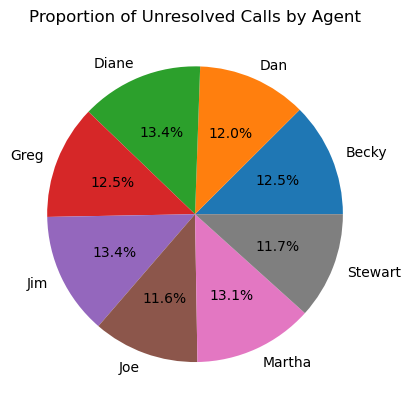

```python
#proportion of unresolved calls by agent
unresolved_counts = cl[cl['Resolved'] == 'N'].groupby('Agent').size()

# Plot a pie chart
plt.pie(unresolved_counts, labels=unresolved_counts.index, autopct='%1.1f%%')
plt.title('Proportion of Unresolved Calls by Agent')
plt.show()
```

proportion of unresolved calls by agents are not customer friendly,all agents need to be more diligent at there duty

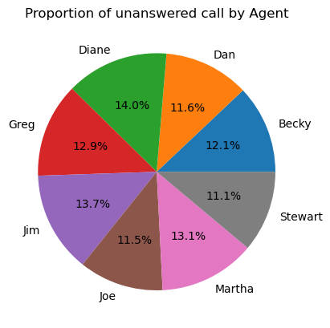

```python
#proportion of unanswered call by agent
Unanswered_counts = cl[cl['Answered (Y/N)'] == 'N'].groupby('Agent').size()
# Plot a pie chart
plt.pie(Unanswered_counts, labels=Unanswered_counts.index, autopct='%1.1f%%')
plt.title('Proportion of unanswered call by Agent')
plt.show()
```

- Diane has the highest percentage of unswered calls
- proportion of unanswered calls by agent are not customer friendly,all agents need to be cautioned

## Recommendation for improving call centre performance and customer satisfaction:

- performance evaluations and setting achievable goals for agents.working critically with customers rating,analizing these ratings so as to know the performance of each agent.
- Recognize and reward high-performing agents to boost morale and motivation within the team.
- Educate customers on self-service options and encourage them to use self-help resources,this would reduce the volume of calls handled by agents also would increase effectiveness.